# Capstone_week2

ZixinZhang

10/11/2020

### Basic summarisation

|  | Entry | Size |
| --- | --- | --- |
| Twitter | 2360148 | 334.48 |
| Blog | 899288 | 267.76 |
| News | 77259 | 20.73 |

As we can see in the table, Twitter has the most elements and largest file size. Blogs comes next and the News the last. As we can see, the number of elements of the Twitter is more than twice the number of Blog, but the size of file of twitter is only slightly larger that the size of Blogs. So we could draw the conclusion that the the average length of entry from Twitter is much shorter than average length of entry from blogs. This conclusion is also proved in the figure below:

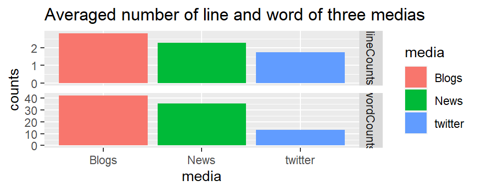

This figure is the summrisation of the average number of lines for each entry from each source. It is important to notice that this is calculated from 20k samples for each source. For these three sources, blogs has the highest values of number of lines and number of words, and the news scored second and twitter has the least numbers of both lines and words. Again this shows that the blogs and news tends to have long sentences and texts on twitter are short.

### Most frequently used words

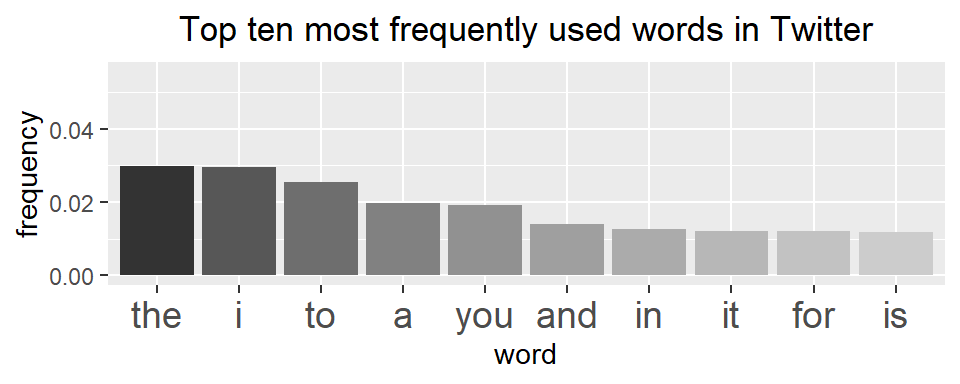

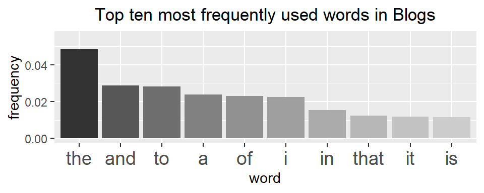

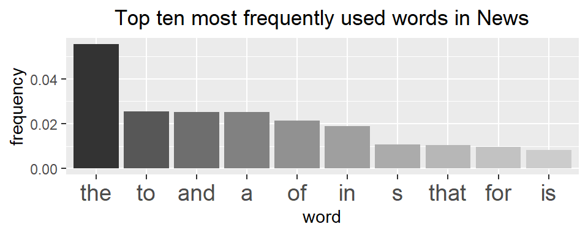

Most frequently used words of these three sources are presented in the figures. We could draw some conclusions:  
1) The word *the* has the highest frequency of all media sources, but with much higher frequencies for News and Blogs than Twitter. It indicates that when people are writing on Twitter, they give less attention to using grammar correctly.  
2) The **personal pronoun** *I*, *you* appear much more times in Text from Twitter than the other media source. It is also expected since people tends to talk about themselves on Twitter.  
3) The single alphabet *s* has a quite high frequency in the text of News, which is worth to being looked into. The reason should be from some incorrectly processing of the language.

### Appendix Code

```r
knitr::opts_chunk$set(
    echo = FALSE,
    warning = FALSE,
    message = FALSE,
    cache = TRUE)

library(tidyr)
library(tm)
library(stringr)
library(ggplot2)
library(dplyr)
library(kableExtra)

set.seed(125)
# setwd('D:/Coursera/Datascience/Capstone')
url = 'https://d396qusza40orc.cloudfront.net/dsscapstone/dataset/Coursera-SwiftKey.zip'
destfile = "Coursera-SwiftKey.zip"
if (!file.exists(destfile)) {
    download.file(fileURL, destfile, method="auto")
    unzip("Coursera-SwiftKey.zip", overwrite = FALSE)}

con <- file("final/en_US/en_US.twitter.txt", "r")
enTwitter <- readLines(con, -1)
close(con)
con <- file("final/en_US/en_US.blogs.txt", "r")
enBlogs <- readLines(con, -1)
close(con)
con <- file("final/en_US/en_US.news.txt", "r")
enNews <- readLines(con, -1)
close(con)
## sum entry and size
sumAll <- data.frame(Entry = c(length(enTwitter),length(enBlogs),length(enNews)),
                     Size = c(object.size(enTwitter),object.size(enBlogs),object.size(enNews))) %>%
    mutate(Size = round(Size/1e06,2))
row.names(sumAll) = c('Twitter', 'Blog', 'News')
## making table
sumAll %>%
  kbl() %>%
  kable_paper(bootstrap_options = "striped", full_width = F)

countLineWords <- function(data, sampleSize)
{
    ## sample the dataset of each category
    dataSample = data[sample(c(1:length(data)), size = sampleSize, replace = F)]
    ## split line by .?! and count
    line = grep('[[:alnum:]]', unlist(strsplit(dataSample, '\\.|\\!|\\?')), value = T)
    lineCount = length(line)
    ## split words and count
    word <- tolower(unlist(sapply(dataSample, function(x) {str_extract_all(x,"[[:alnum:]]+")}), use.names = F))
    wordUnique <- data.frame(table(word))
    wordOrder <- sort(wordUnique$Freq, decreasing = T, index.return = T)
    wordCount <- mutate(data.frame( wordSort = wordUnique$word[wordOrder$ix], times = wordOrder$x), freq = times/length(word))
    ## return result
    result <- list("line" = line, "lineCount" = lineCount, "words" = word, "wordCount" = wordCount)
    return(result)
}

phraseList <- list(Twitter = enTwitter,Blogs = enBlogs,News = enNews)
sampleSize <-  20000
cleanResult <- lapply(phraseList, function(x) countLineWords(x,sampleSize = sampleSize))

dataCount <- data.frame(lineCounts = c(cleanResult$Twitter$lineCount,
                                       cleanResult$Blogs$lineCount,
                                       cleanResult$News$lineCount),
                        wordCounts = c(length(cleanResult$Twitter$words),
                                       length(cleanResult$Blogs$words),
                                       length(cleanResult$News$words))) %>%
    mutate(media = c("twitter", "Blogs", "News"),
           lineCounts = lineCounts/sampleSize,
           wordCounts = wordCounts/sampleSize) %>%
    gather(key = type, value = counts, - media)

twitterTopTen = data.frame(word = head(cleanResult$Twitter$wordCount$word,10), freq  = head(cleanResult$Twitter$wordCount$freq,10))
blogTopTen = data.frame(word = head(cleanResult$Blogs$wordCount$word,10), freq  = head(cleanResult$Blogs$wordCount$freq,10))
newsTopTen = data.frame(word = head(cleanResult$News$wordCount$word,10), freq  = head(cleanResult$News$wordCount$freq,10))
dataTopTen <- list(twitter = twitterTopTen, blog = blogTopTen, news = newsTopTen)
gCount <- ggplot(dataCount, aes(x = media, y = counts, fill = media)) +
    geom_bar(stat = "identity", position = position_dodge()) +
    labs(title = 'Averaged number of line and word of three medias') +
    facet_grid(type ~. , scales = "free")
gCount
gTopTen <- lapply(dataTopTen, function(dataMedia)
    {g <- ggplot(dataMedia, aes(x = reorder(word, -freq), y = freq, fill = reorder(word, -freq))) +
    geom_bar(stat = "identity",show.legend = FALSE)  +
    scale_fill_grey() +
    labs(x = 'word', y = 'frequency') +
    theme(plot.title = element_text(hjust = 0.5),
          axis.text.x  = element_text(size = 14)) +
    ylim(c(0, max(dataTopTen$twitter$freq, dataTopTen$blog$freq, dataTopTen$news$freq)))
    })

gTopTen$twitter + labs(title = 'Top ten most frequently used words in Twitter')
gTopTen$blog + labs(title = 'Top ten most frequently used words in Blogs')
gTopTen$news + labs(title = 'Top ten most frequently used words in News')
```